# Probability 3

Autumn 2025

## Bayes Theorem

## And a little bit of quantum

## Bayes Theorem

- Allows us to *update* our predictions or beliefs based on new information
- Predicts how likely an event is based on *beliefs* and *prior* data.
- Wide-ranging applications from machine learning to medicine to critically analysing arguments.

## Medical diagnosis

- Suppose a patient has a *cough*, and we want to calculate the probability that they have *the flu*.

  One might ask
  - How likely is it that a person has the flu?
  - How likely is it that a person has a cough?
  - How likely is it that you have a cough if you have the flu?

We can use Bayes theorem to do this…

## Bayes Theorem

\[ P(A \mid B) = \frac{P(B \mid A) \times P(A)}{P(B)} \]

- In words: probability that \(A\) will occur given that we have observed \(B\) is \[ \frac{\text{Probability that $B$ occurs given that we observed $A$}\times \text{Total probability of } A}{\text{Total probabability of } B}. \]
- Note: \(P(A \mid B)\) is read “probability of \(A\) given \(B\)”.

## Bayes terminology

\[ P(A \mid B) = \frac{P(B \mid A) \times P(A)}{P(B)} \]

- \(P(A \mid B)\): *posterior probability*
  - How likely is \(A\) given that we have observed \(B\),
  - How likely is *flu* given that we have observed a *cough*
- \(P(B \mid A)\): *likelihood*
  - How likely is \(B\) given that we have observed \(A\),
  - How likely is a *cough* given that we have *flu*.

    Sample lots of flu patients and find the proportion who have a cough.
  - \(P(\text{flu})\): *prior probability*
    - Initial belief that \(A\) will occur.
    - How likely is it that a person has *flu*,

      Proportion of the population who have flu.
  - \(P(\text{cough})\): *total prbability*
    - Probability of \(B\), considering all possible causes
    - How likely is it that a person has a *cough*?

## Applying Bayes to the flu example

- We want to find \(P(\text{flu} \mid \text{cough})\): probability of flu given cough.
- We need to know:
  - \(P(\text{cough} \mid \text{flu})\): probability of cough given flu

    by sampling flu patients \(= 0.6\),
  - \(P(A)\): prior probability of having flu

## Ed has been collecting data…

- The Euler diagram shows:
  - In the entire population (enclosed in the blue box)
  - Those who are good at maths (left),
  - And those who like the Discworld series (right)

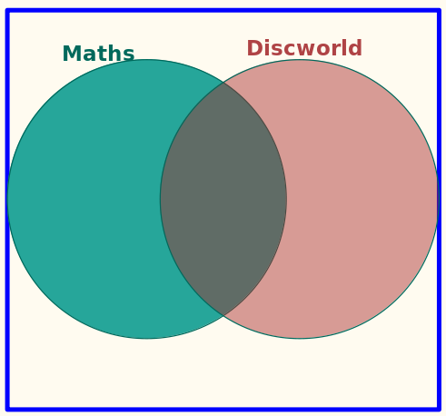

## We sampled \(14\) people…

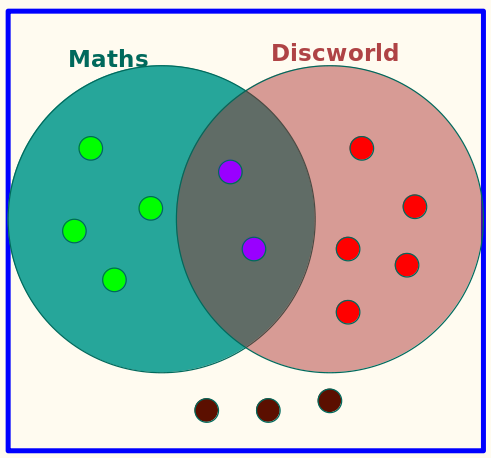

|  | Good at maths | Not good at maths |
| --- | --- | --- |
| Likes Discworld | 2 | 5 |
| Does not like Discworld | 4 | 3 |

From this data, we calculate the probability of each…

|  | Maths | Not Maths | Total Discworld |
| --- | --- | --- | --- |
| Discworld | \(2/14\) | \(5/14\) | \(7/14\) |
| Not Discworld | \(4/14\) | \(3/14\) | \(7/14\) |
| Total Maths | \(6/14\) | \(8/14\) | \(14/14\) |

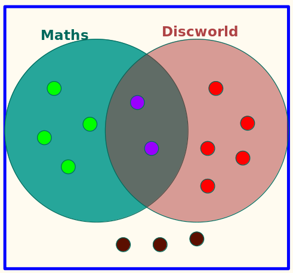

- \(P(M\cap D) = 2/14\),
- \(P(M' \cap D) = 5/14\),
- \(P(M \cap D') = 4/14\),
- \(P(M' \cap D') = 3/14\),
- \(P(M) = 6/14\), \(P(M') = 8/14\),
- \(P(D) = 7/14\), \(P(D') = 7/14\).

## Conditional probability

What is the probability that someone is *not good at maths* given that they *like discworld*? \[ P(M' \mid D) \]

|  | Maths | Not Maths | Total Discworld |
| --- | --- | --- | --- |
| Discworld | \(2/14\) | \(5/14\) | \(7/14\) |

- Total people who like discworld \(= 2 + 5 = 7\)
- People who are not good at maths but like discworld \(= 5\)
- \(P(M' \mid D) = \dfrac{P(M' \cap D)}{P(D)} = \dfrac{5}{7}.\)

## Bayes Theorem Allows

- Mathematical model to calculate the probability of our *beliefs being true* given *real world evidence*.
- We can use this to update our beliefs based on new information.
- We can use Bayesian statistics to model belief systems in order to analyse reasoning,

  i.e., what part of a person’s beliefs leads them to a faulty conclusion.

## Very useful in Computer Science

- Simple mathematical model for real world phenomena
- Widely used in machine learning (maximum a posteriori, Naive Bayes)

https://www.datacamp.com/tutorial/naive-bayes-scikit-learn

## Let’s return to the flu

  We have:
  - \(P(\text{cough} \mid \text{flu}) = 0.6\)
  - \(P(\text{cough} \mid \text{smoker}) = 0.65\)
  - \(P(\text{cough} \mid \text{lung cancer}) = 0.75\)
  - \(P(\text{cough} \mid \text{tuberculosis}) = 0.9\)
- Simply by examining these probabilities, the *most likely* cause of the cough is “*tuberculosis*”.
- Simply by examining these probabilities, the *most likely* cause of the cough is “*tuberculosis*”.

  Would you expect a patient in 21st century England to have tuberculosis?
- Choosing the outcome with the highest probability is called Maximum Likelihood classification.
- Usually, this does not accurately reflect reality.

## Adding prior knowledge

- We need more information such as the prevalence of each disease throughout the population.
  - \(P(\text{flu}) = 0.2\)
  - \(P(\text{smoker}) = 0.3\)
  - \(P(\text{lung cancer}) = 0.08\)
  - \(P(\text{tuberculosis}) = 0.02\)
  - \(P(\text{other}) = 0.4\)
- We can use these *priors* as “weights”,
- I.e., more common causes of coughs should be more likely.

## Naive Bayes Classifier

[output not shown]

- Using our knowledge of prevalence of diseases, we see that *“smoker”* is the most likely cause.

## Naive Bayes

- Here we have used just one *feature* (data point to base our prediction on),

  i.e., the fact that the patient has a cough.
- Machine learning algorithms often use many features (more on that later).
- The word *naive* means that all of these features are statistically independent.

## Notes on Naive Bayes

- We computed only the \(P(B \vert A) \cdot P(A)\) part of Bayes formula,

  for the true probability we’d need to divide by \(P(B)\), but when looking for the maximum, it doesn’t matter.
- As more features are added, more multiplications of decimal numbers between \(0\) and \(1\) are performed, resulting in a very small decimal number.
- To help avoid floating point errors, we usually take logs of both sides,
  - I.e. do \(\log(a) + \log(b) + \log(c) + \ldots\)
  - instead of \(a \cdot b \cdot c \cdots\)

## Quantum fun*! The probabilities of miniscule things

## We’ll be studying

- Applications of probability in quantum mechanics
- High-level overview (since we don’t have time to build up the theory)
- Everything that follows has been *agreed upon* experimentally, although scientists still disagree *why* things happen this way.

## Particle properties

[figure not shown]

Suppose we have a bag of neutrons.

- Neutrons have a property, “spin”, which can be modelled by two binary attributes:
  - shape: *square* or *circle*,
  - colour: *blue* or *green*.

Original credit: MIT professor Alan Adams.

## Shape detection experiment

[interactive chart not shown]

## Colour detection experiment

[interactive chart not shown]

## Combining detectors

[interactive chart not shown]

Colour then shape

[interactive chart not shown]

## Combining detectors

[interactive chart not shown]

Shape then colour

[interactive chart not shown]

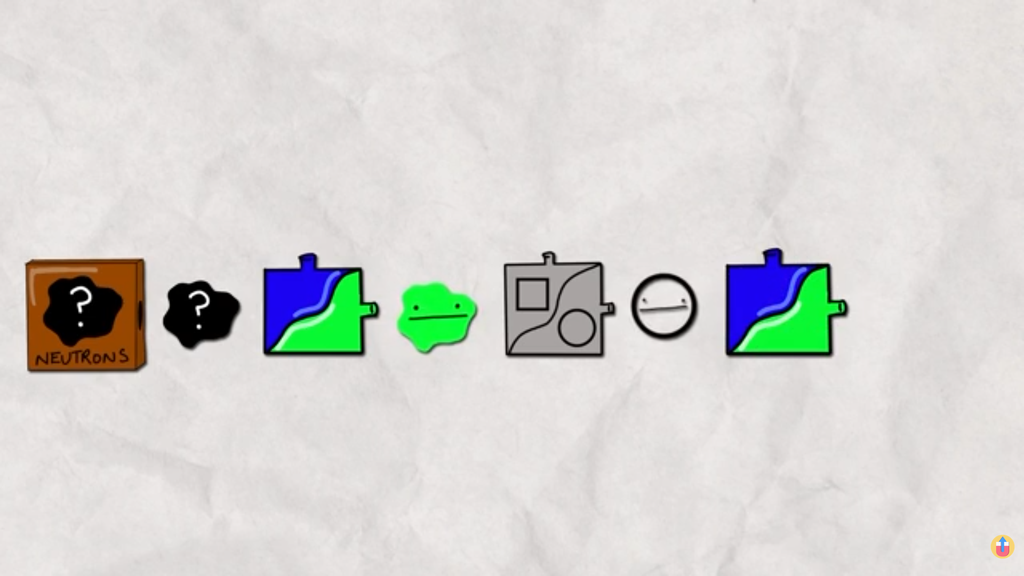

[interactive chart not shown]

How many particles come out *green*?

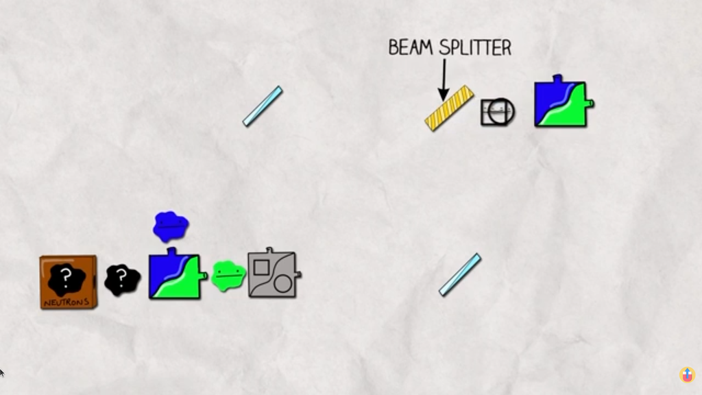

[interactive chart not shown]

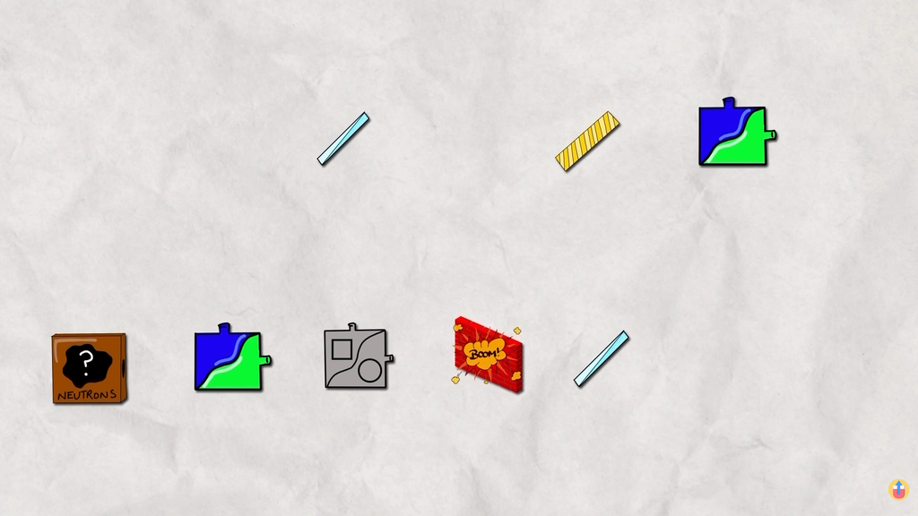

[interactive chart not shown]

## What happened??

> It seems that we are *not allowed* to know both the shape and colour of the neutrans at the same time.

What happened in the *always green* experiment?

1. All took the circle path?
2. All took the square path?
3. Both paths (split in two, duplicate itself)?
4. Neither path?

## Then there must be a fifth option!

> **The neutron is doing something we don’t understand!**
- The word we use to describe this is *superposition*.
- We cannot ktow both the shape and colour.
- More precisely, the neutron *cannot* have both a shape and a colour at the same time.

## Stern-Gerlach Experiment

- [https://en.wikipedia.org/wiki/Stern%E2%80%93Gerlach_experiment]
- [https://www.youtube.com/watch?v=VwWRX9IdblE]

## Superposition

- We cannot know where it is and how fast it is going at the same time.
- Variables come in pairs; the more we measure one, the more the other becomes uncertain.
- *Complementary* or non-commuting variables: energy and time, position and momentum

> It can be expressed in its simplest form as follows: One can never know with perfect accuracy both of those two important factors which determine the movement of one of the smallest particles—its position and its velocity. It is impossible to determine accurately both the position and the direction and speed of a particle at the same instant.

– Werner Heisenberg (Die Physik der Atomkerne, 1952)

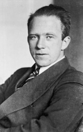

Uncertainty principle proposed in 1927.

[figure not shown]

Quantum objects may be viewed as being in *multiple states* until observed, when the quantum superposition *collapses* to a single observed state.

## Is light a wave or a particle?

## Thomas Young

- British prodigy and polymath.

  Many contributions, including:
  - Elasticity (Young’s modulus),
  - Visual optics (focus and colour perception)
  - Young-Laplace equation (surface tension and capillary attraction)
  - Linguistics and Egyptology

[figure not shown]

13 June 1773 to 10 May 1829

## Oh, and this, too

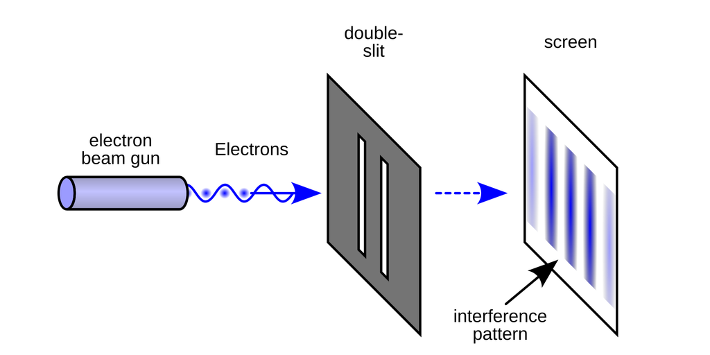

- Coherent light source, e.g., laser;
- Emits photons (particles?) of light at a specific wavelength.
- Solid object with two parallel slits.
- Screen to observe patterns of light passing through the slits.
- Most scientists expected to see two sharp vertical lines on the screen.

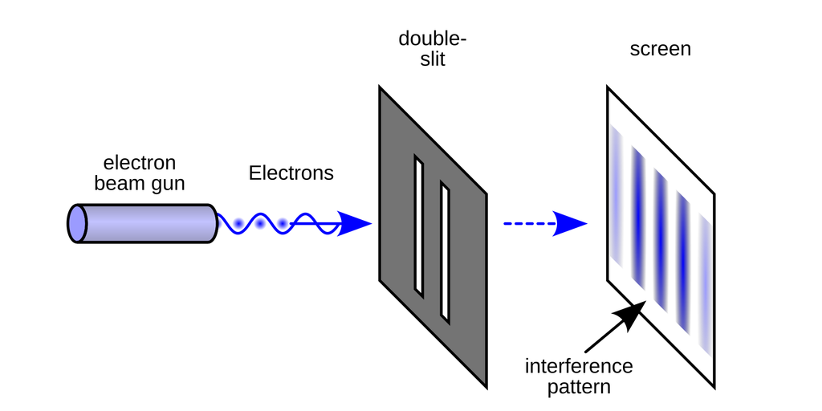

## Observations

Instead, they saw…

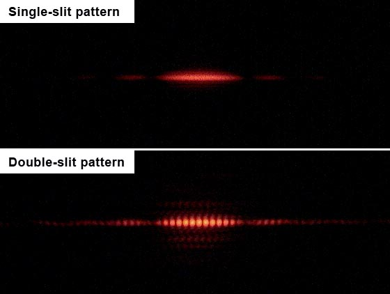

Here, we see light behaving as a wave…

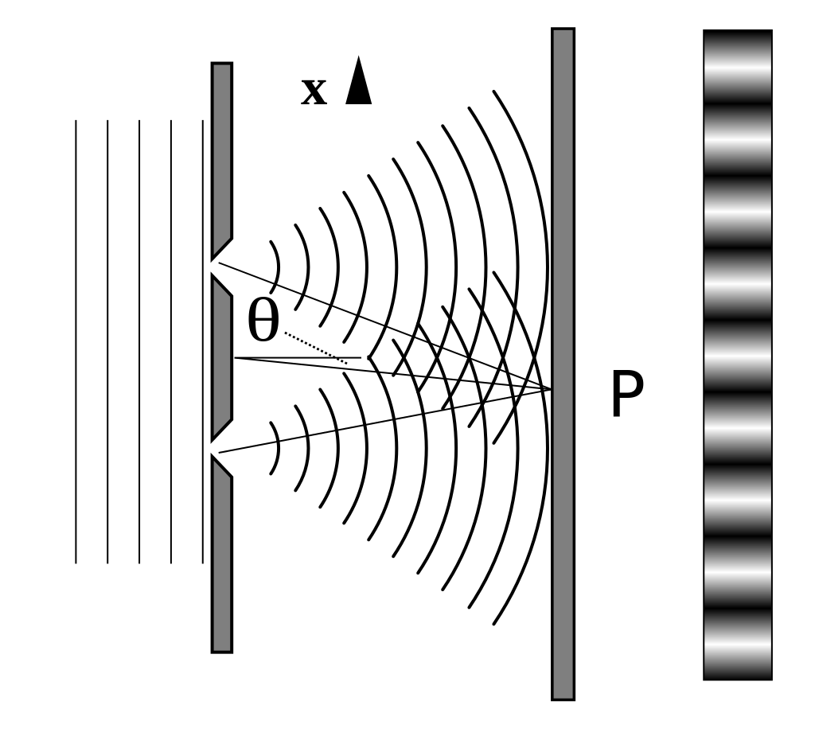

## Wave or particle?

However, if detectors are placed at each slit, each photon of light emitted by the laser is either picked up by one detector or the other – particle behaviour.

## Probabilities of particle positions

- We have seen that quantum objects can exist in multiple states until they are observed, at which point they *collapse* into one state.
- We can use probability distributions to model state measurement.
- E.g., suppose we want to model the position of a particle.

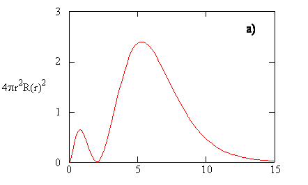

Perform an experiment, take thousands of measurements, and plot their distribution.

## But whyyyy??

- “I think it is more fun than just probability.”

  – Dr Longford
- Interesting application of the maths we have learnt to model complex systems.
- If we use superposition to model bits in computers, we get far different behaviour to that of classical computers.
- It is not intuitive and breaks your brain a bit.

## Lab Task

Build a Spam Email Classifier.

https://www.datacamp.com/tutorial/naive-bayes-scikit-learn